# Bootstrap and count regression

Nguyen Van Truong

12/17/2020

```r
rm(list=ls()) ## Clear the environment
```

Loading libraries:

```r
library(psych)
library(ggplot2)
library(ggExtra)
library(dplyr)
library(MASS)
library(reshape2)
library(glmmTMB)
library(simstudy)
```

### 1. Simulate the dependence of variance on the mean value (Variance-Mean value)

(Figure 1) ## 1.1 Simulate Variance-Mean dependency for count (Poisson and NB) data

```r
variance_mean <- lapply(as.list(as.integer(seq.int(from =  10, to = 2500, length.out = 350))), # the range of sample mean
                   function(i){
                     i = i # the mean of the distribution
                     v <- list()
                     for(j in list(1e-20,0.01,0.1, 1.00,2.00,4)){ # dispersion parametter d in negbin; d = 1e-20 denotes for the case that NB approximate Poisson
                       j = j
                       # variance will be mean+d*mean2
                       Variance <- i + j*(i^2)

                       v0 <- cbind(Mean = i,
                                  Dispersion = j,
                                  Variance = Variance)
                       v[[as.character(j)]] <- v0

                     }
                     vm <- as.data.frame(do.call(rbind, v))


                     })
variance_mean <- as.data.frame(do.call(rbind, variance_mean))
# Names the types of distribution
variance_mean$Distribution <- variance_mean$Dispersion
variance_mean[variance_mean$Dispersion==1e-20,]$Distribution <- "Poisson" # Poisson is approximate NP when d is very small
variance_mean[variance_mean$Dispersion==0.01,]$Distribution <- "NegBinomial, d = 0.01"
variance_mean[variance_mean$Dispersion==0.1,]$Distribution <- "NegBinomial, d = 0.1"

variance_mean[variance_mean$Dispersion==1,]$Distribution <- "NegBinomial, d = 1"
variance_mean[variance_mean$Dispersion==2,]$Distribution <- "NegBinomial, d = 2"
variance_mean[variance_mean$Dispersion==4,]$Distribution <- "NegBinomial, d = 4"
```

## 1.2 Simulate Variance-Mean dependency for Gaussian data

The variance of gaussian data does not depend on the mean value

```r
r<-0.0001 # Correlation coefficient
# Generate a artificial data contained two variables of mean zero with no correlation (coefficient r very small)
mean_var.nor <- data.frame(mvrnorm(n=100, mu=c(0, 0), Sigma=matrix(c(1, r, r, 1), nrow=2),  empirical=TRUE))
# Create a Variance and Mean based on two variables with no correlation to demonstrate that for Gaussian, there is
# no rule between Variance and the mean
mean_var.nor$Variance <- round(7500*(mean_var.nor$X1-min(mean_var.nor$X1)), digits = 0)
mean_var.nor$Mean <- round(750*(mean_var.nor$X2-min(mean_var.nor$X2)), digits = 0)
# pairs.panels(mean_var.nor[,c(3,4)]) # Visualize the correlation between Variance and Mean of Gaussian data
mean_var.nor$Unrestricted_Variance <- "Gaussian"
```

## 1.3 Figure 1 in the paper is visualized with following codes

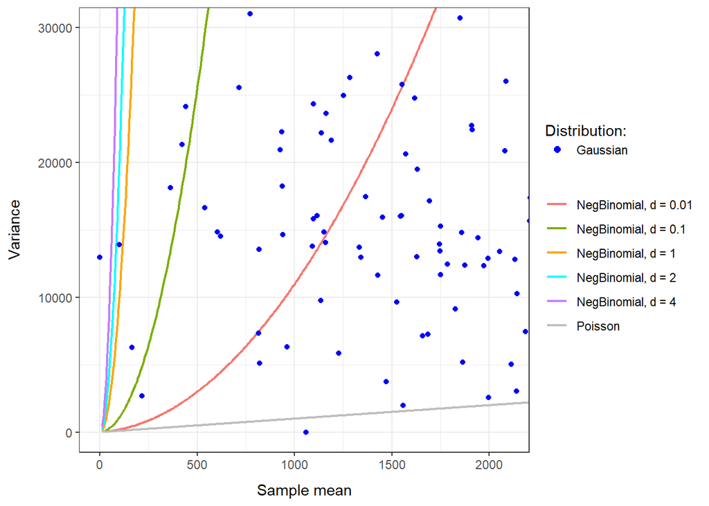

```r
ggplot(data = variance_mean)+
  geom_line(aes(x =Mean, y = Variance, color = Distribution), size = 0.75)+ #, linetype = Distribution
  scale_color_manual(name = "",
                       values = c("Poisson" ="gray",
                                  "NegBinomial, d = 0.01"="#F8766D",
                                  "NegBinomial, d = 0.1"="#7CAE00",
                                  "NegBinomial, d = 1"="orange",
                                  "NegBinomial, d = 2"="cyan",
                                  "NegBinomial, d = 4"="#C77CFF"))+ # change the order of legend labels

  coord_cartesian( xlim = c(0,2100), ylim = c(0,3e4), expand = TRUE, clip = "on")+
  # Put case of normal
  geom_point(data = mean_var.nor,aes(x =Mean, y = Variance, shape = "Gaussian"),
             color = "blue")+

  guides(shape=guide_legend("Distribution:", override.aes=list(shape=16, size = 2)))+ #Change the legend for Gaussian and change the order
  theme_bw()+
  theme(legend.box.spacing = unit(2, "mm"),
        legend.spacing.y = unit(0,"mm"), legend.background = element_blank() )+
  theme(axis.title.y = element_text(margin = margin(t = 0, r = 4, b = 0, l = 0, unit = "mm")))+
  theme(axis.title.x = element_text(margin = margin(t = 3.0, r = 0, b = 0, l = 0, unit = "mm")))+
  labs(x="Sample mean",
       y="Variance")
```

### 2. Simulate the effect of sample rate (or size), extent of dispersion on the accuracy of population estimation (se of OERR) with linear estimator for count data

(Figure 2) In the paper, I used 1000 bootstrap iterations for the simulation. This was time consuming. In this simulation, to save the time, I only use 100 bootstrap iterations. The results will look different to those in the paper. To reproduce the results as in the paper, please increase the bootstrap iterations

With 100 bootstrap iterations, the simulation would take 70 seconds

```r
norm_skew.compare <- lapply(as.list(seq(from =  0.05, to = 1.00, length.out = 26)), # the sample rate
                   function(i){
                     i = i # the sample rate
                     obs <- 10000 # number of observations or population
                     lamda <- 2000 # mean of the outcome distribution
                     nb <- list()
                     nor <- list()
                     for(j in list(1e-6,0.01,0.10,1.00,2.00,4.00)){ # dispersion parametter d in negbin:
                       # variance will be mean+d*mean2
                       def <- defData(varname = "outcome", dist = "negBinomial",
                                      formula = lamda, variance = j, id = "Acc_code")
                       dat <- genData(obs, def)

                       negbin.test <- lapply(as.list(seq(1:100)), # Number of Bootstrap replications in each sample rate i
                            function(h){
                              h = h
                              resam <- dat[sample(x = dat$Acc_code, size = nrow(dat), replace = FALSE),]

                              smp_size <- floor(i * nrow(resam)) # training set = 20%
                              ## set the seed to make your partition reproducible
                              # set.seed(123)
                              train_ind <- base::sample(seq_len(nrow(resam)), size = smp_size)
                              train <- (resam)[train_ind, ]
                              test <- (resam)[-train_ind, ]

                              # Linear estimator
                              linear.estimator = sum(train$outcome)/nrow(train)
                              est.guests.LE = linear.estimator*nrow(test)+sum(train$outcome)

                              observed.guests = sum(test$outcome)+sum(train$outcome)

                              m.performance =cbind(Sample.rate = i,
                                                   Distribution = "NegBinomial",
                                                   var.par = j,
                                                   observed = observed.guests,
                                                   est.guests.LE = est.guests.LE,

                                                   # LE.diff.guests = est.guests.LE - observed.guests,
                                                   LE.diff.ratio = (est.guests.LE - observed.guests)*100/observed.guests

                                                   )
                              m.performance

                            })
                       negbin.test <- do.call(rbind, negbin.test)
                       nb[[as.character(j)]] <- negbin.test

                       # Normal distribution
                       outcome <- round(rnorm(obs, mean = lamda, sd = sqrt(lamda+j*lamda^2) ), digits = 0)
                       Acc_code <- seq.int(from = 1, to = obs)
                       dat <- data.frame(Acc_code = Acc_code,
                                         outcome = outcome)

                       norm.test <- lapply(as.list(seq(1:100)), # Number of Bootstrap replications in each sample rate i
                            function(h){
                              h = h
                              resam <- dat[sample(x = dat$Acc_code, size = nrow(dat), replace = FALSE),]

                              smp_size <- floor(i * nrow(resam)) # training set = 20%
                              ## set the seed to make your partition reproducible
                              # set.seed(123)
                              train_ind <- base::sample(seq_len(nrow(resam)), size = smp_size)
                              train <- (resam)[train_ind, ]
                              test <- (resam)[-train_ind, ]

                              # Linear estimator
                              linear.estimator = sum(train$outcome)/nrow(train)
                              est.guests.LE = linear.estimator*nrow(test)+sum(train$outcome)

                              observed.guests = sum(test$outcome)+sum(train$outcome)

                              m.performance =cbind(Sample.rate = i,
                                                   Distribution = "Gaussian",
                                                   var.par = j,
                                                   observed = observed.guests,
                                                   est.guests.LE = est.guests.LE,

                                                   # LE.diff.guests = est.guests.LE - observed.guests,
                                                   LE.diff.ratio = (est.guests.LE - observed.guests)*100/observed.guests

                                                   )
                              m.performance

                            })
                       norm.test <- do.call(rbind, norm.test)
                       nor[[as.character(j)]] <- norm.test

                     }
                     nb <- as.data.frame(do.call(rbind, nb))
                     nor <- as.data.frame(do.call(rbind, nor))
                     output <- rbind(nb, nor)

                     })
norm_skew.compare <- as.data.frame(do.call(rbind, norm_skew.compare))
# The following codes are to make sure the format of the results of the simulation
norm_skew.compare$Sample.rate <- as.numeric(as.character(norm_skew.compare$Sample.rate))
norm_skew.compare$Distribution <- as.character(norm_skew.compare$Distribution)
norm_skew.compare$var.par <- as.character(norm_skew.compare$var.par)
norm_skew.compare$observed <- as.numeric(as.character(norm_skew.compare$observed))
norm_skew.compare$est.guests.LE <- as.numeric(as.character(norm_skew.compare$est.guests.LE))
norm_skew.compare$LE.diff.ratio <- as.numeric(as.character(norm_skew.compare$LE.diff.ratio))
```

Standard error of the population estimation OERR will be estimated with the following codes

```r
norm_skew.compare.se <- norm_skew.compare %>%
  group_by(Sample.rate,
           Distribution,
           var.par) %>% summarise(iterations = n(),
                                  se.le = sd(LE.diff.ratio))
```

```r
# Defining the types of data
norm_skew.compare.se$Distribution. <- norm_skew.compare.se$Distribution
norm_skew.compare.se[(norm_skew.compare.se$var.par==1e-6&
                       norm_skew.compare.se$Distribution != "Gaussian"),]$Distribution. <- "Poisson"
norm_skew.compare.se[norm_skew.compare.se$var.par==0.01&
                       norm_skew.compare.se$Distribution!="Gaussian",]$Distribution. <- "NegBinomial, d = 0.01"
norm_skew.compare.se[norm_skew.compare.se$var.par==0.1&
                       norm_skew.compare.se$Distribution!="Gaussian",]$Distribution. <- "NegBinomial, d = 0.1"
norm_skew.compare.se[norm_skew.compare.se$var.par==1&
                       norm_skew.compare.se$Distribution!="Gaussian",]$Distribution. <- "NegBinomial, d = 1"
norm_skew.compare.se[norm_skew.compare.se$var.par==2&
                       norm_skew.compare.se$Distribution!="Gaussian",]$Distribution. <- "NegBinomial, d = 2"
norm_skew.compare.se[norm_skew.compare.se$var.par==4&
                       norm_skew.compare.se$Distribution!="Gaussian",]$Distribution. <- "NegBinomial, d = 4"

# Add some points A, B, C, D, E into the figure
a<-norm_skew.compare.se[round(norm_skew.compare.se$Sample.rate,2)==0.20&
                          norm_skew.compare.se$Distribution!="Gaussian",]
a$name <- c("A","B","C","","D","E")
a$xvalue <- round(a$Sample.rate, digits = 2)
a$yvalue <- sprintf("%0.1f",round(a$se.le, digits = 1))
```

Figure 2 in the paper is visualized with following codes

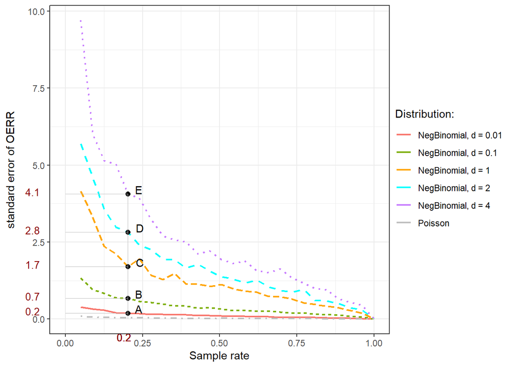

```r
# This design is suitable to export to image600*400 dpi size
ggplot(data = norm_skew.compare.se[norm_skew.compare.se$Distribution.!="Gaussian",], group = Distribution.)+
  geom_line(aes(x =Sample.rate, y = se.le, linetype = Distribution., color = Distribution.), size = 0.75)+

  scale_linetype_discrete(name = "Distribution:",
                          breaks = c("Poisson","NegBinomial, d = 0.01",
                                     "NegBinomial, d = 0.1",
                                     "NegBinomial, d = 1","NegBinomial, d = 2",
                                     "NegBinomial, d = 4"))+ # change the order of legend labels

  scale_color_manual(name = "Distribution:",
                       values = c("Poisson" ="gray",
                                  "NegBinomial, d = 0.01"="#F8766D",
                                  "NegBinomial, d = 0.1"="#7CAE00",
                                  "NegBinomial, d = 1"="orange",
                                  "NegBinomial, d = 2"="cyan",
                                  "NegBinomial, d = 4"="#C77CFF")
                     )+ # change the order of legend labels
  guides(linetype = FALSE)+ # remove legend of linetype

  geom_point(data = a[a$Distribution.!="Poisson",],
             aes(x=Sample.rate, y = se.le), color = "black", size = 2)+
  geom_text(data = a[a$Distribution.!="Poisson",],
            aes(x=Sample.rate, y = se.le, label = name), hjust = -1, vjust = 0, color = "black")+

  geom_text(data = a[a$Distribution.!="Poisson",],
            aes(x=Sample.rate, y = 0, label = xvalue), hjust = 0.75, vjust = 2.75, color = "darkred", size = 3.5)+
  geom_text(data = a[a$Distribution.!="Poisson",],
            aes(x=0, y = se.le, label = yvalue ), hjust = 2.75, vjust = 0.25, color = "darkred", size = 3.5)+

  coord_cartesian(xlim = c(0,1), ylim = c(0,max(norm_skew.compare.se$se.le)), clip = "off")+ # Helps text outside the plot area
  geom_segment(aes(x = a$Sample.rate[1], y=0, xend=a$Sample.rate[1], yend=max(a$se.le)), color = "gray", size=0.05)+

  geom_segment(data = a[a$Distribution.!="Poisson",],
               aes(x = 0, y=a[a$var.par==0.01,]$se.le,
                   xend=a$Sample.rate[1], yend=a[a$var.par==0.01,]$se.le), color = "gray", size=0.05)+
  geom_segment(data = a[a$Distribution.!="Poisson",],
               aes(x = 0, y=a[a$var.par==0.1,]$se.le,
                   xend=a$Sample.rate[1], yend=a[a$var.par==0.1,]$se.le), color = "gray", size=0.05)+
  geom_segment(data = a[a$Distribution.!="Poisson",],
               aes(x = 0, y=a[a$var.par==1,]$se.le,
                   xend=a$Sample.rate[1], yend=a[a$var.par==1,]$se.le), color = "gray", size=0.05)+
  geom_segment(data = a[a$Distribution.!="Poisson",],
               aes(x = 0, y=a[a$var.par==2,]$se.le,
                   xend=a$Sample.rate[1], yend=a[a$var.par==2,]$se.le), color = "gray", size=0.05)+
  geom_segment(data = a[a$Distribution.!="Poisson",],
               aes(x = 0, y=a[a$var.par==4,]$se.le,
                   xend=a$Sample.rate[1], yend=a[a$var.par==4,]$se.le), color = "gray", size=0.0)+

  theme_bw()+
  theme(legend.position = "right", legend.box = "vertical", legend.box.just = "top",
        legend.justification = "left", legend.direction = "vertical", legend.box.spacing = unit(0, "cm"),
        legend.spacing.y = unit(0.25,"cm"), legend.background = element_blank(),
        axis.title.y = element_text(margin = margin(t = 0, r = 4, b = 0, l = 0, unit = "mm")))+

  labs(x="Sample rate",
       y="standard error of OERR")
```

### 3. Simulate the effectiveness of using auxiliary variable in regression to increase accuracy of population estimation.

Linear estimator is used as a benchmark method. The standard error of OERR is used as an evaluation indicator. Results are visualized in the (Figure 3) In the paper, 1000 bootstrap iterations are used for simulation. In the following codes, I use only 10 bootstrap iterations to save the time. Please increase the bootstrap iterations to reproduce the results as in the paper. 1 bootstrap, simulation includes 25*5 = 125 models Simulation would take 1 minutes for simulation with 1 bootstrap iterations

```r
t0 <- Sys.time()
negbin.se_r <- lapply(as.list(seq(from =  0.01, to = 0.99, length.out = 25)), # the correlation coefficient, 0.01 denotes very weak (no) correlation
                   function(r){
                     r = r # the correlation coefficient
                     obs <- 10000 # number of observations

                     lamda <- c(65,2000) # mean of predictor and outcome, take information from dat2016.12k

                     se_r <- list()
                     for(j in list(0.01,0.10,1.00,2.00,4.00)){ # dispersion parametter d in negbin: 1e-6,0.01,0.10,1.00,2.00,4.00 (impose dispersion d too small may cause notification "Model convergence problem; non-positive-definite Hessian matrix". This notification may not effect the simulation results)
                       dispersion <- c(j, j) # variance = mean + dispersion*mean^2; in the dat2016.12 dispersion = ~3.6

                       dat <- genCorGen(obs, nvars = 2, params1 = lamda,
                                      params2 = dispersion, dist = "negBinomial",
                                      rho = r, corstr = "cs", wide = TRUE)
                       dat <- rename(dat, "predictor"="V1", "outcome"="V2", "Acc_code" = "id")
                       # r <- cor(dat[,c(2,3)])[1,2]
                       dat$predictor <- dat$predictor+1

                       list1 <- lapply(as.list(seq(1:10)), # Number of Bootstrap replications in each sample rate i
                            function(h){
                              h = h
                              resam <- dat[sample(x = dat$Acc_code, size = nrow(dat), replace = FALSE),]

                              smp_size <- floor(0.2 * nrow(resam)) # training set = 20%
                              ## set the seed to make your partition reproducible
                              # set.seed(123)
                              train_ind <- base::sample(seq_len(nrow(resam)), size = smp_size) # drawn n samples Without replacement
                              train <- (resam)[train_ind, ]
                              test <- (resam)[-train_ind, ]

                              # m1.poi.fix: Poisson regression with fixed variance
                              m1.poi.fix <- glmmTMB(outcome ~ I(log(predictor)),
                                                    ziformula = ~ 0,
                                                    dispformula = ~ I(log(predictor)),
                                                    data = train,
                                                    family = nbinom2())


                              test$m1.fitted <- predict(m1.poi.fix, newdata = test, type = "response")
                              m1.est.guests = sum(test$m1.fitted)+sum(train$outcome)

                              # Linear estimator

                              linear.estimator = sum(train$outcome)/nrow(train)
                              est.guests.LE = linear.estimator*nrow(test)+sum(train$outcome)

                              observed.guests = sum(test$outcome)+sum(train$outcome)

                              m.performance =cbind(dispersion = dispersion,
                                                   correlation.coef = r,
                                                   observed = observed.guests,

                                                   # m1.est.guests = m1.est.guests,
                                                   # m1.diff.guests = m1.est.guests - observed.guests,
                                                   m1.diff.ratio = (m1.est.guests - observed.guests)*100/observed.guests,

                                                   # LE.est.guests = est.guests.LE,
                                                   # LE.diff.guests = est.guests.LE - observed.guests,
                                                   LE.diff.ratio = (est.guests.LE - observed.guests)*100/observed.guests

                                                   )
                              m.performance

                            })
                       list1 <- do.call(rbind, list1)


                       se_r[[as.character(j)]] <- list1
                       }
                     se_r <- as.data.frame(do.call(rbind, se_r))



                     })
negbin.se_r <- as.data.frame(do.call(rbind, negbin.se_r))
t1 <- Sys.time()
t1-t0 # Time consumed for the Simulation
```

```
## Time difference of 9.029994 mins
```

The simulation results are visualized with following codes (Figure 3 in the paper)

```r
negbin.se <- negbin.se_r %>%
  group_by(dispersion,
           correlation.coef) %>%
  summarise(obs = n(),
            se.reg = sd(m1.diff.ratio),
            se.le = sd(LE.diff.ratio))
```

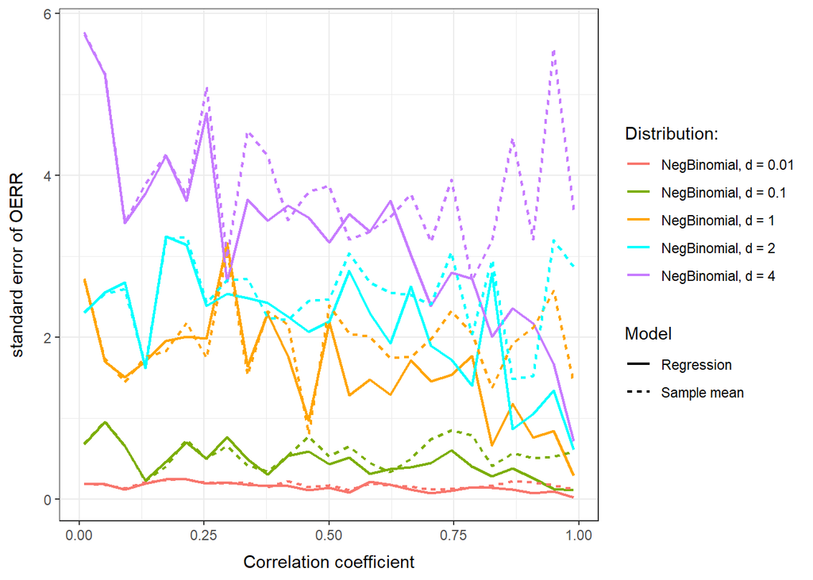

```r
negbin.se.plot <- negbin.se[,c(1,2,4,5)] %>%
  melt(.,
       id.vars = c("dispersion", "correlation.coef"),
       variable.name = "Model")
negbin.se.plot$Model <- as.character(negbin.se.plot$Model)
negbin.se.plot$Model[negbin.se.plot$Model=="se.reg"] <- "Regression"
negbin.se.plot$Model[negbin.se.plot$Model=="se.le"] <- "Sample mean"

negbin.se.plot$Distribution <- negbin.se.plot$dispersion

negbin.se.plot[negbin.se.plot$dispersion==0.01,]$Distribution <- "NegBinomial, d = 0.01"
negbin.se.plot[negbin.se.plot$dispersion==0.1,]$Distribution <- "NegBinomial, d = 0.1"
negbin.se.plot[negbin.se.plot$dispersion==1,]$Distribution <- "NegBinomial, d = 1"
negbin.se.plot[negbin.se.plot$dispersion==2,]$Distribution <- "NegBinomial, d = 2"
negbin.se.plot[negbin.se.plot$dispersion==4,]$Distribution <- "NegBinomial, d = 4"

ggplot(negbin.se.plot[negbin.se.plot$Distribution!="Poisson",])+
  geom_line(aes(x =correlation.coef, y = value,linetype = Model, color = Distribution), size =0.75)+
  scale_color_manual(name = "Distribution:",
                       values = c("NegBinomial, d = 0.01"="#F8766D",
                                  "NegBinomial, d = 0.1"="#7CAE00",
                                  "NegBinomial, d = 1"="orange",
                                  "NegBinomial, d = 2"="cyan",
                                  "NegBinomial, d = 4"="#C77CFF"))+
  theme_bw()+
  theme(axis.title.y = element_text(margin = margin(t = 0, r = 4, b = 0, l = 0, unit = "mm")))+
  theme(axis.title.x = element_text(margin = margin(t = 2.5, r = 0, b = 0, l = 0, unit = "mm")))+
  # theme(legend.position = "right", legend.box = "vertical", legend.box.just = "top",
  #       legend.justification = "left", legend.direction = "vertical", legend.box.spacing = unit(0, "cm"),
  #       legend.spacing.y = unit(0.25,"cm"), legend.background = element_blank() )+

  labs(x = "Correlation coefficient",
       y = "standard error of OERR")
```

### 4. Estimation of population (total guests) with the tourism accommodation data in December 2016 in Japan.

Loading the data

```r
load("dat2016.12K.RData")
```

## 4.1 Explore the distribution of outcome variable (Table 1 in the paper)

The dispersion parameter d ~ 3.69 suggesting that the data is highly over-dispersed. Therefore, it will highly affect the estimation of population total

```r
data.frame(Mean=sapply(na.omit(dat2016.12K[,c(5,2,3,4)]),mean),
           Min = sapply(na.omit(dat2016.12K[,c(5,2,3,4)]),min),
           Max = sapply(na.omit(dat2016.12K[,c(5,2,3,4)]),max),
           Sd=sapply(na.omit(dat2016.12K[,c(5,2,3,4)]),sd))
```

```
##                      Mean Min   Max         Sd
## Guests.Persons 1681.28430   0 98281 3229.77919
## Rooms            65.78816   1  3560  103.95523
## Capacity        151.61030   2  7037  238.11808
## Employees        36.03980   0  1964   74.10507
```

```r
# Dispersion parameter d of the data is roughly estimated as:
((sd(dat2016.12K$Guests.Persons))^2 - mean(dat2016.12K$Guests.Persons))/(mean(dat2016.12K$Guests.Persons)^2)
```

```
## [1] 3.689719
```

## 4.2 Utilise Pearson’s correlation coefficient r to identify the auxiliary variable that most beneficial to the population total estimation

Figure 4 in the paper and 95%CI of Pearson’s correlation coefficients

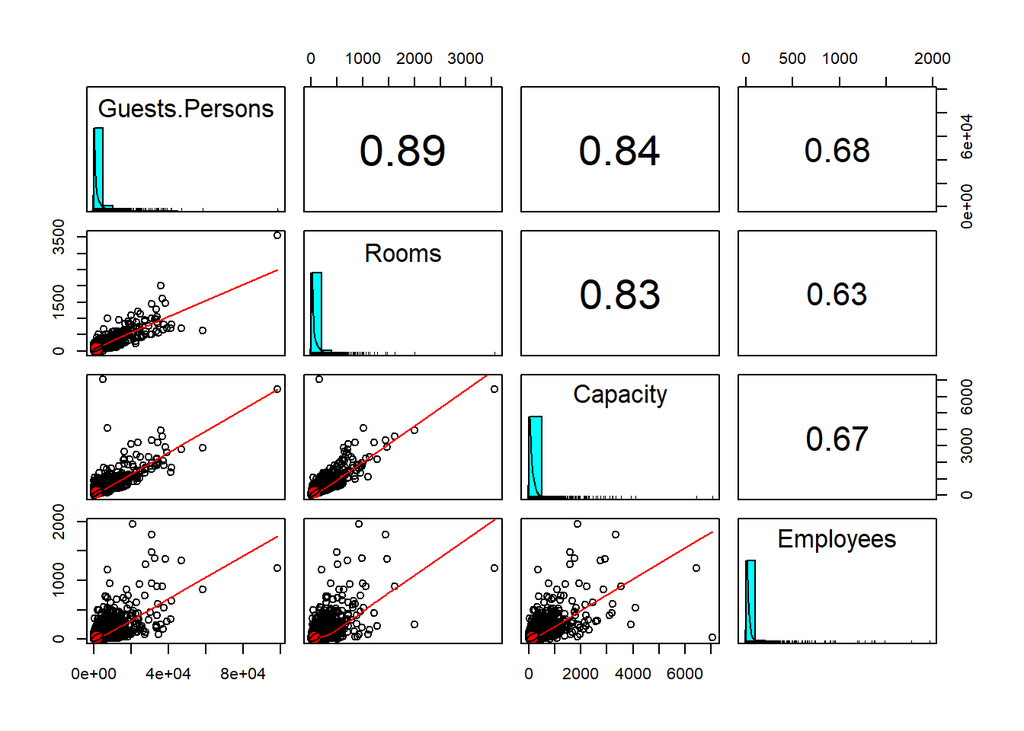

```r
pairs.panels(dat2016.12K[,c(5,2,3,4)], scale = TRUE, smooth = TRUE, pch = 1)
```

```r
# 95%CI of bivariate Pearson's correlation coefficients
cor.test(dat2016.12K$Guests.Persons, dat2016.12K$Rooms, method = "pearson")$conf.int[1:2]
```

```
## [1] 0.8861918 0.8941307
```

```r
cor.test(dat2016.12K$Guests.Persons, dat2016.12K$Capacity, method = "pearson")$conf.int[1:2]
```

```
## [1] 0.8381363 0.8491593
```

```r
cor.test(dat2016.12K$Guests.Persons, dat2016.12K$Employees, method = "pearson")$conf.int[1:2]
```

```
## [1] 0.6727006 0.6931088
```

```r
cor.test(dat2016.12K$Rooms, dat2016.12K$Capacity, method = "pearson")$conf.int[1:2]
```

```
## [1] 0.8256121 0.8374126
```

```r
cor.test(dat2016.12K$Rooms, dat2016.12K$Employees, method = "pearson")$conf.int[1:2]
```

```
## [1] 0.6160843 0.6392614
```

```r
cor.test(dat2016.12K$Capacity, dat2016.12K$Employees, method = "pearson")$conf.int[1:2]
```

```
## [1] 0.6543192 0.6756514
```

## 4.3 Explore distribution of the outcome variable (guests)

The codes below visualize the distribution of Guests.Persons (right panel in Figure 5)

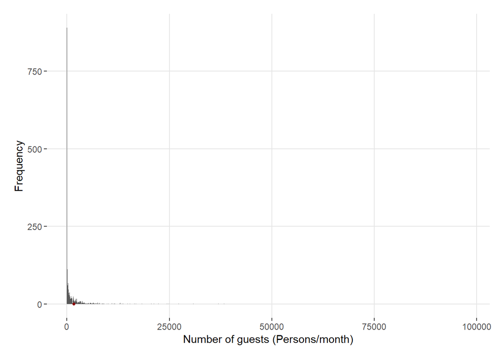

```r
ggplot(data = dat2016.12K, aes(x = Guests.Persons)) +
  geom_histogram(binwidth = 10) +
  geom_point(aes(x = mean(Guests.Persons), y = 0), color = "darkred", size = 1)+ #This point denotes the mean value of the Guests.Person
  # ggtitle("Distribution of guests staying at the
  # surveyed accommodation properties in December 2016") +
  xlab("Number of guests (Persons/month)") +
  ylab("Frequency") +
  theme(panel.background = element_rect(fill = FALSE),
        panel.grid.major = element_line(colour = "gray90"),
        panel.grid.minor = element_blank(),
        plot.margin = margin(0.5, 0.5, 0.5, 0.5, "cm")
        )
```

Figure 5 (full, including 3 panels)

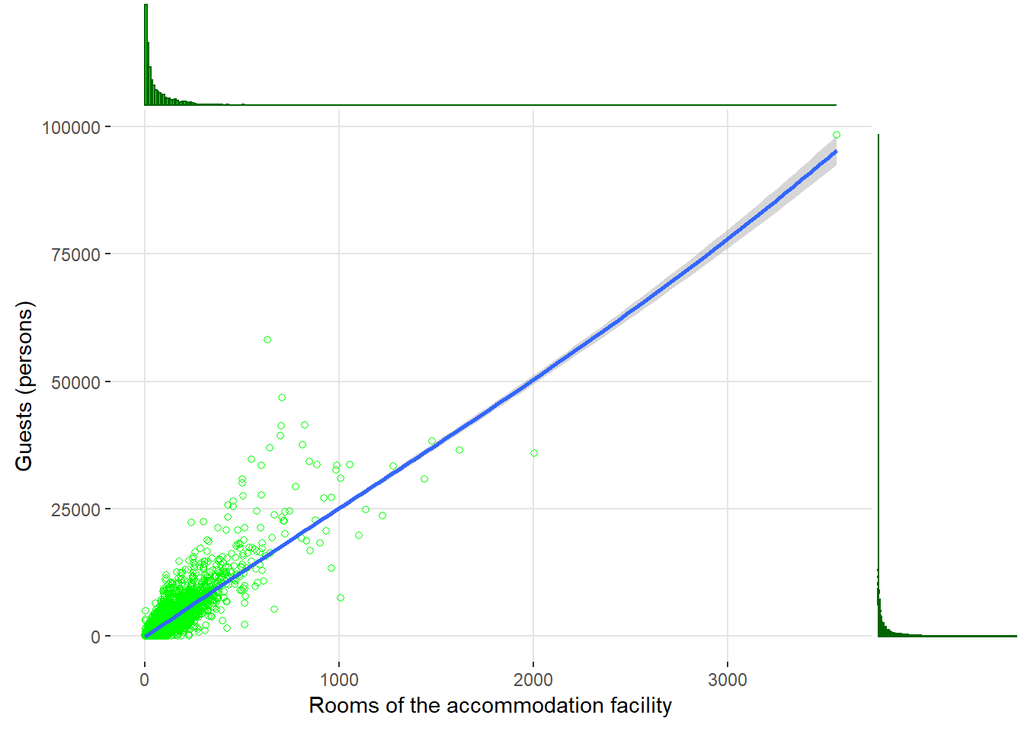

```r
p <- ggplot(data = dat2016.12K, aes(x = Rooms, y = Guests.Persons)) +
  geom_point(shape = 1, color = "green")+
  stat_smooth(formula = y ~ x, method = "loess")+
  xlab("Rooms of the accommodation facility") +
  ylab("Guests (persons)") +
  theme(panel.background = element_rect(fill = FALSE),
        panel.grid.major = element_line(colour = "gray90"),
        panel.grid.minor = element_blank()
        )

ggExtra::ggMarginal(p, type = "histogram",  col = "darkgreen", fill="green",
                    xparams = list(binwidth = 10),  yparams = list(binwidth = 50))
```

## 4.4 Comparison the effectiveness of (zero-inflated, over-dispersed, longtail count NB) regression with the benchmark method (linear estimator)

The analysis procedure, which is presented in Figure 6 (in the paper), is done with the codes below

In the paper, the results are obtained with 2500 bootstrap iteration. Here, I use 25 bootstrap iterations to save the time. Please increase bootstrap iterations to reproduce the results as presented in the paper. It would take 10 minutes for 25 bootstrap iterations

```r
t0<-Sys.time()
performance <- lapply(list(0.05, 0.1, 0.2, 0.3, 0.4, 0.5, 0.6, 0.7, 0.8, 0.85, 0.9, 0.95), # The rate of training set
                   function(i){
                     i = i # This is the rate of training set (which is presumed as survey sample)
                     list1 <- lapply(as.list(seq(1:25)), # Number of Bootstrap replications in each sample rate i
                            function(h){
                              h = h
                              # Create bootstrap sample
                              resam <- dat2016.12K[sample(x = nrow(dat2016.12K),
                                                          size = nrow(dat2016.12K),
                                                          replace = TRUE),]
                              smp_size <- floor(i * nrow(resam))
                              train_ind <- base::sample(seq_len(nrow(resam)), size = smp_size)
                              # Drawn a training set of size n (sample rate i) with simple random sampling without replacement (SRSWOR)
                              train <- (resam)[train_ind, ]
                              # The test set will be used to validate the estimation
                              test <- (resam)[-train_ind, ]

                              # m12.HNB.vari: Hurdle negative binomial regression with varied variance
                              m12.HNB.vari <- glmmTMB(Guests.Persons ~ I(log(Rooms)), # Logarithmic Rooms to make it the same scale with Guests.Persons. Because the link function in the logarithm form
                                                    ziformula = ~ I(log(Rooms)), # zero-inflation as f(Rooms)
                                                    dispformula = ~ I(log(Rooms)), # varied dispersion
                                                    data = train,
                                                    family = truncated_nbinom2(link = "log"))
                              test$m12.fitted <- predict(m12.HNB.vari, newdata = test, type = "response")
                              m12.est.guests = sum(test$m12.fitted)+sum(train$Guests.Persons)
                              m12.AIC = AIC(m12.HNB.vari)
                              m12.BIC = BIC(m12.HNB.vari)
                              m12.LL = logLik(m12.HNB.vari)[1]

                              # Linear estimator
                              train.guests = sum(train$Guests.Persons)
                              linear.estimator = sum(train$Guests.Persons)/nrow(train)
                              est.guests.LE = linear.estimator*nrow(test)+sum(train$Guests.Persons)

                              observed.guests = sum(test$Guests.Persons)+sum(train$Guests.Persons)

                              m.performance =cbind(train.rate = i,
                                                   observed.guests = observed.guests,
                                                   m12.est.guests = m12.est.guests,
                                                   # m12.diff.guests = m12.est.guests - observed.guests,
                                                   m12.diff.ratio = (m12.est.guests - observed.guests)*100/observed.guests,
                                                   m12.AIC = m12.AIC,
                                                   m12.BIC = m12.BIC,
                                                   m12.LL = m12.LL,

                                                   LE.est.guests = est.guests.LE,
                                                   # LE.diff.guests = est.guests.LE - observed.guests,
                                                   LE.diff.ratio = (est.guests.LE - observed.guests)*100/observed.guests

                                                   )
                              m.performance

                            })
                     list1 <- do.call(rbind, list1)

                     })
performance <- as.data.frame(do.call(rbind, performance))
Sys.time()-t0
```

```
## Time difference of 9.190686 mins
```

```r
HNB.reg <- performance[,c("train.rate", "observed.guests", "m12.diff.ratio")]
names(HNB.reg) <- c("train.rate", "observed.guests", "diff.ratio")
HNB.reg$model <- rep("HNB", nrow(HNB.reg))

LE <- performance[,c("train.rate", "observed.guests", "LE.diff.ratio")]
names(LE) <- c("train.rate", "observed.guests", "diff.ratio")
LE$model <- rep("LE", nrow(LE))
performance_melt <- rbind(HNB.reg, LE)
```

# Visualize the bootstrap sampling distribution of OERR before the Bias correction

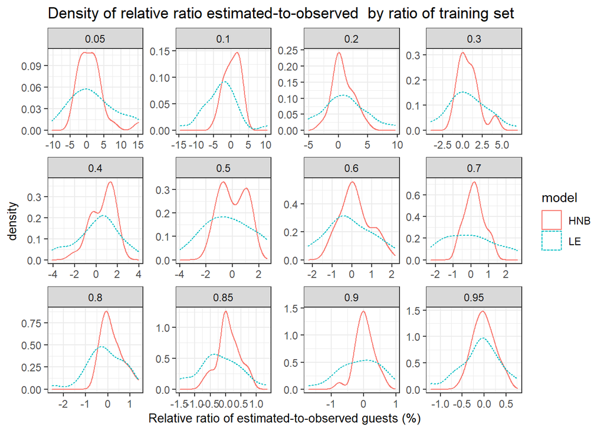

```r
performance_melt %>%
  ggplot()+
  geom_density(aes(x=diff.ratio, colour = model, linetype = model))+
  facet_wrap(~train.rate, scales = "free")+
  theme_bw()+
  theme(legend.position="right",plot.caption=element_text(hjust=0,size=8),
        axis.title=element_text(size=10),
        plot.title=element_text(size=13))+
  labs(x="Relative ratio of estimated-to-observed guests (%)",
       title="Density of relative ratio estimated-to-observed  by ratio of training set"
       )
```

# Bias correction

```r
correct <- lapply(list(0.05, 0.1, 0.2, 0.3, 0.4, 0.5, 0.6, 0.7, 0.8, 0.85, 0.9, 0.95),
                   function(i){
                     i = i
                     correct.list <- list()
                     for(j in list("HNB", "LE")) {# HNB.reg, Hurdle Negative binomial regression estimator; LE, Linear estimator
                       j = j
                       estimate <- performance_melt[(performance_melt$train.rate==i &
                                                       performance_melt$model == j),]
                       estimate$est.guests <- estimate$observed.guests*(1+estimate$diff.ratio/100)
                       estimate$diff.guests <- estimate$est.guests-estimate$observed.guests
                       estimate$bias <- mean(estimate$diff.ratio)
                       estimate$se <- sd(estimate$diff.ratio)
                       # Test if se/bias <0.25? if this is satisfied, then that is fine to do correction
                       # (See P128, Introduction to the Bootstrap, Bradley Efron)
                       estimate$se_bias <- estimate$bias /estimate$se
                       estimate$est.guests_corrected <- estimate$est.guests*(1-estimate$bias/100)
                       estimate$diff.ratio.corrected <- estimate$diff.ratio - estimate$bias
                       estimate$lw2.5 <- quantile(estimate$diff.ratio.corrected, 0.025)
                       estimate$lw0.5 <- quantile(estimate$diff.ratio.corrected, 0.5)
                       estimate$lw97.5 <- quantile(estimate$diff.ratio.corrected, 0.975)
                       correct.list[[j]] <- estimate
                     }

                     correct.list <- as.data.frame(do.call(rbind, correct.list))
                     })
correct <- as.data.frame(do.call(rbind, correct))
correct$model <- factor(correct$model,
                        levels = c("HNB", "LE"),
                        labels = c("HNB", "LE"))
corrected <- correct[correct$model!="LE",c(1,3,4)]
corrected$Bias_correction <- "HNB WOBC"
corrected2 <- correct[correct$model!="LE",c(1,11,4)]
corrected2 <- rename(corrected2, "diff.ratio" = "diff.ratio.corrected")
corrected2$Bias_correction <- "HNB WBC"
performance.le <- performance_melt[performance_melt$model=="LE",c(1,3,4)]
performance.le$Bias_correction <- "LE"
performance.le$model <- as.factor(performance.le$model)
correct.fn <- bind_rows(corrected,corrected2, performance.le)
correct.fn <- rename(correct.fn, "Model" = "model")
```

# Visualize the results after the Bias correction, figure 8

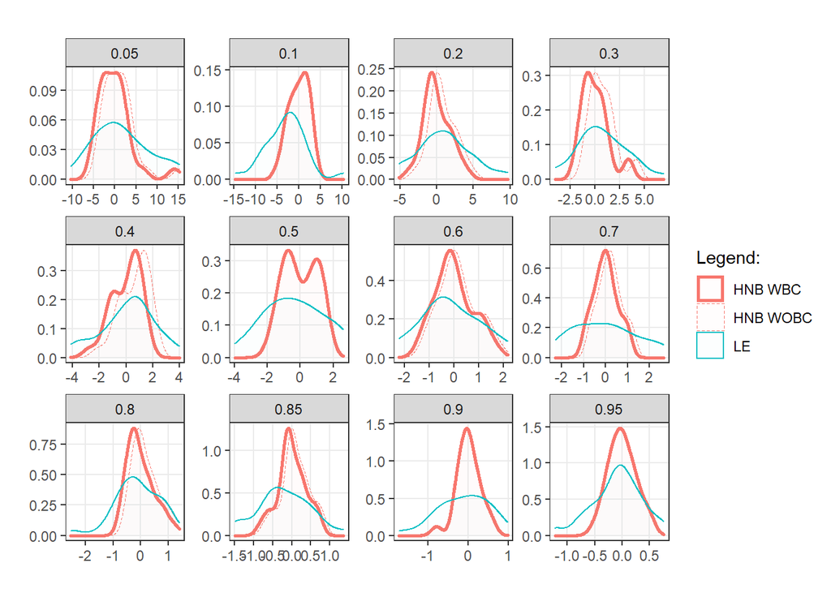

```r
ggplot(data = correct.fn, aes(x=diff.ratio, group = Bias_correction))+
  geom_density(aes(colour = Bias_correction, linetype = Bias_correction,
                   fill = Bias_correction, size = Bias_correction))+
  scale_color_manual(values = c("#F8766D","#F8766D", "#00BFC4", "#C77CFF"))+
  scale_fill_manual(values = alpha(c("#F8766D","#F8766D", "#00BFC4", "#C77CFF"), .01))+
  scale_linetype_manual(values = c("solid", "dashed", "solid", "solid"))+
  labs(colour="Legend:")+ # Legend title
  labs(linetype="Legend:")+
  labs(fill="Legend:")+
  labs(size="Legend:")+
  scale_size_manual(values = c(1.0, 0.25, 0.5, 0.5))+
  facet_wrap(~train.rate, scales = "free")+
  theme_bw()+

  theme(legend.position="right",
        plot.caption=element_text(hjust=0,size=8),
        axis.title=element_text(size=10),
        plot.title=element_text(size=13),
        panel.grid.minor = element_blank())+
  labs(x="", y="",title="")
```